# Investigate_a_Dataset

### Questions

- Does the place yoy play in affect the results of the game?
- what is the most develope team?

### uploading data

```python
# importing libraries

import pandas as pd
import numpy as np
import seaborn as sns
import matplotlib.pyplot as plt
```

### Reading data

```python
soccer=pd.read_csv("Match.csv")
```

### Exploring data

Now i will see the first 5 lines to take a quick look on the data

```python
print(type(soccer))
print (soccer.head())
# After discussing the structure of the data and any problems that need to be
#   cleaned, perform those cleaning steps in the second part of this section.
```

```
<class 'pandas.core.frame.DataFrame'>
   id country_id               league_id     season  stage             date  \
0   1    Belgium  Belgium Jupiler League  2008/2009      1  17/08/2008 0:00
1   2    Belgium  Belgium Jupiler League  2008/2009      1  16/08/2008 0:00
2   3    Belgium  Belgium Jupiler League  2008/2009      1  16/08/2008 0:00
3   4    Belgium  Belgium Jupiler League  2008/2009      1  17/08/2008 0:00
4   5    Belgium  Belgium Jupiler League  2008/2009      1  16/08/2008 0:00

   match_api_id   home_team_api_id   away_team_api_id  home_team_goal  \
0        492473           KRC Genk       Beerschot AC               1
1        492474   SV Zulte-Waregem   Sporting Lokeren               0
2        492475  KSV Cercle Brugge     RSC Anderlecht               0
3        492476           KAA Gent          RAEC Mons               5
4        492477      FCV Dender EH  Standard de Liège               1

      ...      away_player_10  away_player_11  goal  shoton  shotoff  \
0     ...                 NaN             NaN   NaN     NaN      NaN
1     ...                 NaN             NaN   NaN     NaN      NaN
2     ...                 NaN             NaN   NaN     NaN      NaN
3     ...                 NaN             NaN   NaN     NaN      NaN
4     ...                 NaN             NaN   NaN     NaN      NaN

   foulcommit  card  cross  corner  possession
0         NaN   NaN    NaN     NaN         NaN
1         NaN   NaN    NaN     NaN         NaN
2         NaN   NaN    NaN     NaN         NaN
3         NaN   NaN    NaN     NaN         NaN
4         NaN   NaN    NaN     NaN         NaN

[5 rows x 85 columns]
```

`i knew that contains of 85 column`

Now I want to search for null values and check on datatype

```python
soccer.info()
```

```
<class 'pandas.core.frame.DataFrame'>
RangeIndex: 1746 entries, 0 to 1745
Data columns (total 85 columns):
id                  1746 non-null int64
country_id          1746 non-null object
league_id           1746 non-null object
season              1746 non-null object
stage               1746 non-null int64
date                1746 non-null object
match_api_id        1746 non-null int64
home_team_api_id    1746 non-null object
away_team_api_id    1746 non-null object
home_team_goal      1746 non-null int64
away_team_goal      1746 non-null int64
home_player_X1      1538 non-null float64
home_player_X2      1538 non-null float64
home_player_X3      1538 non-null float64
home_player_X4      1538 non-null float64
home_player_X5      1538 non-null float64
home_player_X6      1538 non-null float64
home_player_X7      1538 non-null float64
home_player_X8      1538 non-null float64
home_player_X9      1538 non-null float64
home_player_X10     1538 non-null float64
home_player_X11     1538 non-null float64
away_player_X1      1538 non-null float64
away_player_X2      1538 non-null float64
away_player_X3      1538 non-null float64
away_player_X4      1538 non-null float64
away_player_X5      1538 non-null float64
away_player_X6      1538 non-null float64
away_player_X7      1538 non-null float64
away_player_X8      1538 non-null float64
away_player_X9      1538 non-null float64
away_player_X10     1538 non-null float64
away_player_X11     1538 non-null float64
home_player_Y1      1538 non-null float64
home_player_Y2      1538 non-null float64
home_player_Y3      1538 non-null float64
home_player_Y4      1538 non-null float64
```

[output cut: 35 more lines]

```
away_player_7       1525 non-null float64
away_player_8       1516 non-null float64
away_player_9       1505 non-null float64
away_player_10      1518 non-null float64
away_player_11      1513 non-null float64
goal                18 non-null object
shoton              18 non-null object
shotoff             18 non-null object
foulcommit          18 non-null object
card                18 non-null object
cross               18 non-null object
corner              17 non-null object
possession          17 non-null object
dtypes: float64(66), int64(5), object(14)
memory usage: 1.1+ MB
```

`i descovered that the there are many coloumns contain missing values`

i want to know some calculates about the data

```python
soccer.describe()
```

|  | id | stage | match_api_id | home_team_goal | away_team_goal | home_player_X1 | home_player_X2 | home_player_X3 | home_player_X4 | home_player_X5 | ... | away_player_2 | away_player_3 | away_player_4 | away_player_5 | away_player_6 | away_player_7 | away_player_8 | away_player_9 | away_player_10 | away_player_11 |
| --- | --- | --- | --- | --- | --- | --- | --- | --- | --- | --- | --- | --- | --- | --- | --- | --- | --- | --- | --- | --- | --- |
| count | 1746.000000 | 1746.000000 | 1.746000e+03 | 1746.000000 | 1746.000000 | 1538.0 | 1538.000000 | 1538.000000 | 1538.000000 | 1538.000000 | ... | 1509.000000 | 1520.000000 | 1505.000000 | 1518.000000 | 1519.000000 | 1525.000000 | 1516.000000 | 1505.000000 | 1518.000000 | 1513.000000 |
| mean | 873.500000 | 15.659794 | 1.116793e+06 | 1.612257 | 1.191867 | 1.0 | 2.076073 | 4.017555 | 6.059818 | 7.127438 | ... | 112266.918489 | 105218.562500 | 114514.550166 | 129573.121212 | 105403.359447 | 103978.424262 | 128667.971636 | 136561.853821 | 121142.886034 | 140507.690681 |
| std | 504.171102 | 8.968966 | 5.141729e+05 | 1.293691 | 1.125562 | 0.0 | 0.517802 | 0.469309 | 0.529234 | 2.119559 | ... | 122611.447541 | 112739.542357 | 106129.536759 | 104785.437350 | 124729.770122 | 110978.702342 | 127622.679913 | 121995.689480 | 118974.653606 | 123714.065222 |
| min | 1.000000 | 1.000000 | 4.890420e+05 | 0.000000 | 0.000000 | 1.0 | 1.000000 | 2.000000 | 2.000000 | 1.000000 | ... | 3329.000000 | 3329.000000 | 3329.000000 | 4863.000000 | 5272.000000 | 2770.000000 | 2770.000000 | 2770.000000 | 5016.000000 | 5016.000000 |
| 25% | 437.250000 | 8.000000 | 6.655982e+05 | 1.000000 | 0.000000 | 1.0 | 2.000000 | 4.000000 | 6.000000 | 8.000000 | ... | 37953.000000 | 37440.000000 | 38322.000000 | 39145.000000 | 36944.500000 | 37866.000000 | 38290.000000 | 38778.000000 | 37956.500000 | 38732.000000 |
| 50% | 873.500000 | 16.000000 | 1.032790e+06 | 1.000000 | 1.000000 | 1.0 | 2.000000 | 4.000000 | 6.000000 | 8.000000 | ... | 39859.000000 | 39739.500000 | 69713.000000 | 109332.000000 | 38945.000000 | 39578.000000 | 69653.000000 | 104406.000000 | 68114.000000 | 104404.000000 |
| 75% | 1309.750000 | 23.000000 | 1.717860e+06 | 2.000000 | 2.000000 | 1.0 | 2.000000 | 4.000000 | 6.000000 | 8.000000 | ... | 154276.000000 | 157375.000000 | 172147.000000 | 178096.000000 | 148307.500000 | 166179.000000 | 178482.000000 | 182605.000000 | 181054.000000 | 197848.000000 |
| max | 1746.000000 | 34.000000 | 1.980072e+06 | 7.000000 | 7.000000 | 1.0 | 8.000000 | 8.000000 | 8.000000 | 9.000000 | ... | 641042.000000 | 563215.000000 | 630950.000000 | 641042.000000 | 688876.000000 | 658786.000000 | 659493.000000 | 676625.000000 | 671331.000000 | 671331.000000 |

8 rows × 71 columns

`knew the str and max and min values`

### Cleaning data

To clean data we must make sure that there is no missing values

```python
#searching for nulls
soccer.isnull().sum()
```

```
id                     0
country_id             0
league_id              0
season                 0
stage                  0
date                   0
match_api_id           0
home_team_api_id       0
away_team_api_id       0
home_team_goal         0
away_team_goal         0
home_player_X1       208
home_player_X2       208
home_player_X3       208
home_player_X4       208
home_player_X5       208
home_player_X6       208
home_player_X7       208
home_player_X8       208
home_player_X9       208
home_player_X10      208
home_player_X11      208
away_player_X1       208
away_player_X2       208
away_player_X3       208
away_player_X4       208
away_player_X5       208
away_player_X6       208
away_player_X7       208
away_player_X8       208
                    ...
home_player_1        214
home_player_2        244
home_player_3        224
home_player_4        233
home_player_5        240
home_player_6        226
home_player_7        218
home_player_8        229
home_player_9        234
home_player_10       229
home_player_11       230
away_player_1        221
away_player_2        237
away_player_3        226
away_player_4        241
away_player_5        228
away_player_6        227
away_player_7        221
away_player_8        230
away_player_9        241
away_player_10       228
away_player_11       233
goal                1728
shoton              1728
shotoff             1728
foulcommit          1728
card                1728
cross               1728
corner              1729
possession          1729
Length: 85, dtype: int64
```

`As i predicted , there are many coloumns contain missing values`

i want to make sure that there is no duplicates

```python
soccer.duplicated().sum()
```

```
0
```

now let's delete missing values

```python
#deleting nulls
soccer.dropna()
```

|  | id | country_id | league_id | season | stage | date | match_api_id | home_team_api_id | away_team_api_id | home_team_goal | ... | away_player_10 | away_player_11 | goal | shoton | shotoff | foulcommit | card | cross | corner | possession |
| --- | --- | --- | --- | --- | --- | --- | --- | --- | --- | --- | --- | --- | --- | --- | --- | --- | --- | --- | --- | --- | --- |
| 1728 | 1729 | England | England Premier League | 2008/2009 | 1 | 17/08/2008 0:00 | 489042 | Manchester United | Newcastle United | 1 | ... | 34574.0 | 37799.0 | <goal><value><comment>n</comment><stats><goals... | <shoton><value><stats><blocked>1</blocked></st... | <shotoff><value><stats><shotoff>1</shotoff></s... | <foulcommit><value><stats><foulscommitted>1</f... | <card><value><comment>y</comment><stats><ycard... | <cross><value><stats><crosses>1</crosses></sta... | <corner><value><stats><corners>1</corners></st... | <possession><value><comment>56</comment><event... |
| 1729 | 1730 | England | England Premier League | 2008/2009 | 1 | 16/08/2008 0:00 | 489043 | Arsenal | West Bromwich Albion | 1 | ... | 25922.0 | 27267.0 | <goal><value><comment>n</comment><stats><goals... | <shoton><value><stats><blocked>1</blocked></st... | <shotoff><value><stats><shotoff>1</shotoff></s... | <foulcommit><value><stats><foulscommitted>1</f... | <card /> | <cross><value><stats><crosses>1</crosses></sta... | <corner><value><stats><corners>1</corners></st... | <possession><value><comment>65</comment><event... |
| 1730 | 1731 | England | England Premier League | 2008/2009 | 1 | 16/08/2008 0:00 | 489044 | Sunderland | Liverpool | 0 | ... | 24635.0 | 30853.0 | <goal><value><comment>n</comment><stats><goals... | <shoton><value><stats><blocked>1</blocked></st... | <shotoff><value><stats><shotoff>1</shotoff></s... | <foulcommit><value><stats><foulscommitted>1</f... | <card><value><comment>y</comment><stats><ycard... | <cross><value><stats><crosses>1</crosses></sta... | <corner><value><stats><corners>1</corners></st... | <possession><value><comment>45</comment><event... |
| 1731 | 1732 | England | England Premier League | 2008/2009 | 1 | 16/08/2008 0:00 | 489045 | West Ham United | Wigan Athletic | 2 | ... | 127857.0 | 34466.0 | <goal><value><comment>n</comment><stats><goals... | <shoton><value><stats><shoton>1</shoton></stat... | <shotoff><value><stats><shotoff>1</shotoff></s... | <foulcommit><value><stats><foulscommitted>1</f... | <card><value><comment>y</comment><stats><ycard... | <cross><value><stats><crosses>1</crosses></sta... | <corner><value><stats><corners>1</corners></st... | <possession><value><comment>50</comment><event... |
| 1733 | 1734 | England | England Premier League | 2008/2009 | 1 | 16/08/2008 0:00 | 489047 | Everton | Blackburn Rovers | 2 | ... | 34176.0 | 30646.0 | <goal><value><comment>n</comment><stats><goals... | <shoton><value><stats><shoton>1</shoton></stat... | <shotoff><value><stats><shotoff>1</shotoff></s... | <foulcommit><value><stats><foulscommitted>1</f... | <card><value><comment>y</comment><stats><ycard... | <cross><value><stats><crosses>1</crosses></sta... | <corner><value><stats><corners>1</corners></st... | <possession><value><comment>46</comment><event... |
| 1734 | 1735 | England | England Premier League | 2008/2009 | 1 | 16/08/2008 0:00 | 489048 | Middlesbrough | Tottenham Hotspur | 2 | ... | 41157.0 | 23949.0 | <goal><value><comment>dg</comment><event_incid... | <shoton><value><stats><shoton>1</shoton></stat... | <shotoff><value><stats><shotoff>1</shotoff></s... | <foulcommit><value><stats><foulscommitted>1</f... | <card><value><comment>y</comment><stats><ycard... | <cross><value><stats><corners>1</corners></sta... | <corner><value><stats><corners>1</corners></st... | <possession><value><comment>49</comment><event... |
| 1735 | 1736 | England | England Premier League | 2008/2009 | 1 | 16/08/2008 0:00 | 489049 | Bolton Wanderers | Stoke City | 3 | ... | 23288.0 | 23314.0 | <goal><value><comment>n</comment><stats><goals... | <shoton><value><stats><blocked>1</blocked></st... | <shotoff><value><stats><shotoff>1</shotoff></s... | <foulcommit><value><stats><foulscommitted>1</f... | <card><value><comment>y</comment><stats><ycard... | <cross><value><event_incident_typefk>123</even... | <corner><value><stats><corners>1</corners></st... | <possession><value><comment>58</comment><event... |
| 1736 | 1737 | England | England Premier League | 2008/2009 | 1 | 16/08/2008 0:00 | 489050 | Hull City | Fulham | 2 | ... | 34248.0 | 24741.0 | <goal><value><comment>n</comment><stats><goals... | <shoton><value><stats><shoton>1</shoton></stat... | <shotoff><value><stats><shotoff>1</shotoff></s... | <foulcommit><value><stats><foulscommitted>1</f... | <card><value><comment>y</comment><stats><ycard... | <cross><value><stats><crosses>1</crosses></sta... | <corner><value><stats><corners>1</corners></st... | <possession><value><comment>49</comment><event... |
| 1737 | 1738 | England | England Premier League | 2008/2009 | 1 | 17/08/2008 0:00 | 489051 | Chelsea | Portsmouth | 4 | ... | 30348.0 | 30830.0 | <goal><value><comment>n</comment><stats><goals... | <shoton><value><stats><shoton>1</shoton></stat... | <shotoff><value><stats><shotoff>1</shotoff></s... | <foulcommit><value><stats><foulscommitted>1</f... | <card><value><comment>y</comment><stats><ycard... | <cross><value><stats><crosses>1</crosses></sta... | <corner><value><stats><corners>1</corners></st... | <possession><value><comment>57</comment><event... |
| 1738 | 1739 | England | England Premier League | 2008/2009 | 10 | 29/10/2008 0:00 | 489132 | Manchester United | West Ham United | 2 | ... | 33781.0 | 24773.0 | <goal><value><comment>n</comment><stats><goals... | <shoton><value><stats><shoton>1</shoton></stat... | <shotoff><value><stats><shotoff>1</shotoff></s... | <foulcommit><value><stats><foulscommitted>1</f... | <card><value><comment>y</comment><stats><ycard... | <cross><value><stats><corners>1</corners></sta... | <corner><value><stats><corners>1</corners></st... | <possession><value><comment>59</comment><event... |
| 1739 | 1740 | England | England Premier League | 2008/2009 | 10 | 29/10/2008 0:00 | 489133 | Arsenal | Tottenham Hotspur | 4 | ... | 31921.0 | 40755.0 | <goal><value><comment>n</comment><stats><goals... | <shoton><value><stats><blocked>1</blocked></st... | <shotoff><value><stats><shotoff>1</shotoff></s... | <foulcommit><value><stats><foulscommitted>1</f... | <card><value><comment>y</comment><stats><ycard... | <cross><value><stats><crosses>1</crosses></sta... | <corner><value><stats><corners>1</corners></st... | <possession><value><comment>63</comment><event... |
| 1740 | 1741 | England | England Premier League | 2008/2009 | 10 | 29/10/2008 0:00 | 489134 | Middlesbrough | Manchester City | 2 | ... | 33974.0 | 51553.0 | <goal><value><comment>p</comment><stats><penal... | <shoton><value><stats><shoton>1</shoton></stat... | <shotoff><value><stats><shotoff>1</shotoff></s... | <foulcommit><value><stats><foulscommitted>1</f... | <card><value><comment>y</comment><stats><ycard... | <cross><value><stats><crosses>1</crosses></sta... | <corner><value><stats><corners>1</corners></st... | <possession><value><comment>48</comment><event... |
| 1741 | 1742 | England | England Premier League | 2008/2009 | 10 | 29/10/2008 0:00 | 489135 | Bolton Wanderers | Everton | 0 | ... | 24160.0 | 30735.0 | <goal><value><comment>n</comment><stats><goals... | <shoton><value><stats><shoton>1</shoton></stat... | <shotoff><value><stats><shotoff>1</shotoff></s... | <foulcommit><value><stats><foulscommitted>1</f... | <card><value><comment>y</comment><stats><ycard... | <cross><value><stats><crosses>1</crosses></sta... | <corner><value><stats><corners>1</corners></st... | <possession><value><comment>55</comment><event... |
| 1742 | 1743 | England | England Premier League | 2008/2009 | 10 | 29/10/2008 0:00 | 489136 | Hull City | Chelsea | 0 | ... | 30679.0 | 37804.0 | <goal><value><comment>n</comment><stats><goals... | <shoton><value><stats><shoton>1</shoton></stat... | <shotoff><value><stats><shotoff>1</shotoff></s... | <foulcommit><value><stats><foulscommitted>1</f... | <card><value><comment>y</comment><stats><ycard... | <cross><value><stats><crosses>1</crosses></sta... | <corner><value><stats><corners>1</corners></st... | <possession /> |
| 1744 | 1745 | England | England Premier League | 2008/2009 | 10 | 29/10/2008 0:00 | 489138 | Liverpool | Portsmouth | 1 | ... | 63520.0 | 30830.0 | <goal><value><comment>p</comment><stats><penal... | <shoton><value><stats><shoton>1</shoton></stat... | <shotoff><value><stats><shotoff>1</shotoff></s... | <foulcommit><value><stats><foulscommitted>1</f... | <card><value><comment>y</comment><stats><ycard... | <cross><value><stats><crosses>1</crosses></sta... | <corner><value><stats><corners>1</corners></st... | <possession><value><comment>57</comment><event... |

15 rows × 85 columns

### EDA

**First:** Does the place yoy play in affect the results?

```python
# Step 1: Calculate match results for each team
# Create a list to store match results
away_matches = []
home_matches = []
# Function to calculate improvement
def calculate_improvement(points_last, points_first):
    if points_last is not None and points_first is not None:
        return points_last - points_first
    return None  # Handle cases where data is missing

# Iterate through each row to extract home and away team results

for _, row in soccer.iterrows():
    # Home team results
    home_matches.append({
        'team_id': row['home_team_api_id'],
        'season': row['season'],
        'points': 3 if row['home_team_goal'] > row['away_team_goal'] else (1 if row['home_team_goal'] == row['away_team_goal'] else 0)
    })

    # Away team results
    away_matches.append({
        'team_id': row['away_team_api_id'],
        'season': row['season'],
        'points': 3 if row['away_team_goal'] > row['home_team_goal'] else (1 if row['away_team_goal'] == row['home_team_goal'] else 0)
    })

# Convert matches list to a DataFrame
home_matches_soccer = pd.DataFrame(home_matches)
away_matches_soccer = pd.DataFrame(away_matches)
#print(matches_soccer.head())

# Step 2: Aggregate data by team and season
home_matches_soccer_agg = home_matches_soccer.groupby(['season']).agg({
    'points': 'sum'
}).reset_index()

away_matches_soccer_agg = away_matches_soccer.groupby(['season']).agg({
    'points': 'sum'
}).reset_index()


improvement_df=[]
away_matches_dict = away_matches_soccer_agg.set_index('season')['points'].to_dict()
print(away_matches_dict)

# Iterate through each team in the first season
for i in range(len(home_matches_soccer_agg)):
    season = home_matches_soccer_agg.loc[i, 'season']
    home_points = home_matches_soccer_agg.loc[i, 'points']

    away_points = away_matches_dict.get(season, None)

    # Append the data to the list
    improvement_df.append({
        'sesson': season,
        'home_points': home_points,
        'away_points': away_points
        })



# Convert the list of dictionaries to a DataFrame
home_away_points = pd.DataFrame(improvement_df)

# Display the DataFrame
print(home_away_points)
```

```
{'2008/2009': 351, '2009/2010': 237, '2010/2011': 248, '2011/2012': 233, '2012/2013': 296, '2013/2014': 14, '2014/2015': 282, '2015/2016': 257}
   away_points  home_points     sesson
0          351          552  2008/2009
1          237          342  2009/2010
2          248          410  2010/2011
3          233          422  2011/2012
4          296          365  2012/2013
5           14           20  2013/2014
6          282          378  2014/2015
7          257          404  2015/2016
```

`If we compared between each the two players we can find that th home_player win more than away_player`

Now i will make agraph that shows the difference

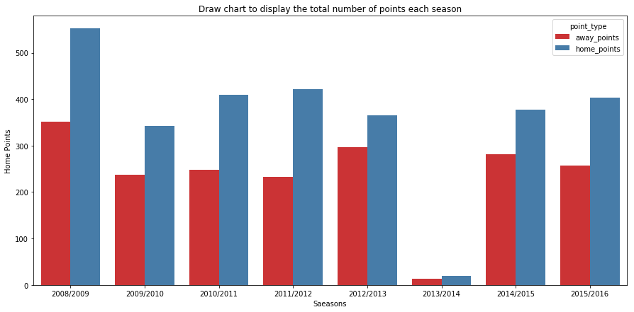

```python
#confirm the size of graph
plt.figure(figsize=(15, 7))
# Reshape the data for Seaborn
reshaped_df = home_away_points.melt(id_vars='sesson', var_name='point_type', value_name='points')
sns.barplot(data=reshaped_df, x="sesson", y="points", hue= "point_type", palette='Set1')

plt.xlabel("Saeasons")
plt.ylabel("Home Points")
plt.title("Draw chart to display the total number of points each season")
plt.show()
```

**Second:** what is the most develope team?

Now i will know the develope teams as different seasons

```python
# Step 1: Calculate match results for each team
# Create a list to store match results
matches = []

# Function to calculate improvement
def calculate_improvement(points_last, points_first):
    if points_last is not None and points_first is not None:
        return points_last - points_first
    return None  # Handle cases where data is missing

# Iterate through each row to extract home and away team results
for _, row in soccer.iterrows():
    # Home team results
    matches.append({
        'team_id': row['home_team_api_id'],
        'season': row['season'],
        'points': 3 if row['home_team_goal'] > row['away_team_goal'] else (1 if row['home_team_goal'] == row['away_team_goal'] else 0)
    })

    # Away team results
    matches.append({
        'team_id': row['away_team_api_id'],
        'season': row['season'],
        'points': 3 if row['away_team_goal'] > row['home_team_goal'] else (1 if row['away_team_goal'] == row['home_team_goal'] else 0)
    })

# Convert matches list to a DataFrame
matches_soccer = pd.DataFrame(matches)


# Step 2: Aggregate data by team and season
team_season_stats = matches_soccer.groupby(['team_id', 'season']).agg({
    'points': 'sum'
}).reset_index()



first_season = team_season_stats.groupby('team_id').first().reset_index()

last_season = team_season_stats.groupby('team_id').last().reset_index()


improvement_df=[]
last_season_dict = last_season.set_index('team_id')['points'].to_dict()
# Iterate through each team in the first season
for i in range(len(first_season)):
    team_id = first_season.loc[i, 'team_id']
    points_first = first_season.loc[i, 'points']

    # Fetch points from last_season using team_id
    points_last = last_season_dict.get(team_id, None)  # Use None or a default value if team_id is not found

    # Append the data to the list
    improvement_df.append({
        'team_id': team_id,
        'points_first': points_first,
        'points_last': points_last,
        'points_improvement': calculate_improvement(points_last ,points_first)
    })




# Convert the list of dictionaries to a DataFrame
improvement_df = pd.DataFrame(improvement_df)
improvement_df = improvement_df.sort_values(by='points_improvement', ascending=False)
```

Now i will make graph for the most 5 developed teams

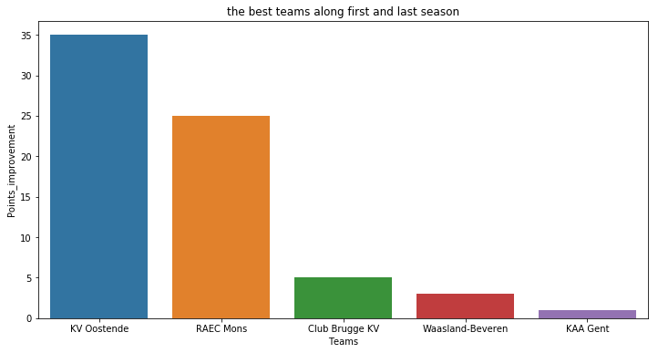

```python
# Display the DataFrame
result_of_top_five = improvement_df.head(5)
plt.figure(figsize=(12, 6))
sns.barplot(data=result_of_top_five, x="team_id", y="points_improvement")


plt.xlabel("Teams")
plt.ylabel("Points_improvement")
plt.title("the best teams along first and last season")
plt.show()
```

`Now we can see the defferent between them`

### limitation

- there are many missing values